# Informe Final del Ensayo de Aptitud (EA)

Medición de Gases Contaminantes Criterio SO₂, CO, O₃, NO, NO₂

Laboratorio CALAIRE

2026-01-24

# 1. Introduccion

Este informe presenta los resultados del Ensayo de Aptitud (EA) para la medicion de gases contaminantes criterio en aire cero, conforme a la norma ISO/IEC 17043:2023 y los metodos estadisticos de la norma ISO 13528:2022. El documento resume la informacion del esquema, la participacion, la metodologia y los resultados obtenidos.

## 1.1. Información del Proveedor y del esquema

**Alcance:** Este Ensayo de Aptitud (EA) por comparación interlaboratorio abarca la medición de los gases contaminantes criterio SO₂, CO, O₃, NO y NO₂ en aire cero, según lo definido en el EA-2026-01.

**Objetivo Principal:** Evaluar el desempeño de los laboratorios participantes en la medición de los gases contaminantes criterio, conforme a los requisitos de la norma ISO/IEC 17043:2023 y utilizando los métodos estadísticos de la norma ISO 13528:2022.

## 1.2. Confidencialidad y Uso del Informe

La identidad de los participantes es confidencial y solo conocida por el personal autorizado de CALAIRE involucrado en la operación del esquema de EA. Se utilizan códigos de laboratorio anonimizados en este informe para asegurar la confidencialidad, según lo estipulado en la política de confidencialidad del laboratorio. Este informe es para uso de los participantes y, cuando aplique, de sus organismos de acreditación o autoridades regulatorias. Cualquier otro uso debe ser autorizado por CALAIRE.

## 1.3. Roles de Autorización y Personal Clave

La organización, ejecución y evaluación de este EA se realizó bajo la responsabilidad del Laboratorio CALAIRE. Los roles clave involucrados fueron:

**Coordinador EA:** CZ  
**Profesional Calidad Aire:** WS  
**Ingeniero Operativo:** FM  
**Profesional de Gestión de Calidad:** JO

## 1.4. Participantes e Instrumentación

En esta ronda del EA participaron 3 laboratorios. A continuación, se lista a los participantes (mediante código asignado).

Tabla 2. Participantes del Ensayo de Aptitud

[output not shown]

# 2. Descripción del Ensayo y Metodología

## 2.1. Ítems de Ensayo y Producción

**Descripción:** Los ítems de ensayo consistieron en atmósferas de gas SO₂, CO, O₃, NO, NO₂ en aire cero, generadas dinámicamente y suministradas a los participantes a través de un colector de distribución (manifold) de vidrio inerte.

**Método de Producción:**

- **O₃:** El O₃ es generado dinámicamente mediante un generador de ozono, trazable con un fotómetro nivel 2 en la cadena de trazabilidad de ozono.
- **SO₂, CO, NO, NO₂:** Generados por dilución dinámica de Materiales Certificados de Referencia (MCR) trazables, utilizando controladores de flujo másico calibrados.

Tabla 3. Niveles de concentración del ítem de ensayo (Valores de Referencia)

[output not shown]

*Los valores de concentración obedecen a los intervalos de medición establecidos en la normativa vigente y lo estipulado en los métodos US-EPA.

**Instrucciones a Participantes:** Se solicitó a los participantes reportar [3] mediciones promedio de [1 h] para cada nivel de concentración a partir de los niveles de concentración minutales.

## 2.2. Homogeneidad y Estabilidad de los Ítems de EA

Dado que los ítems de ensayo se generan dinámicamente y se miden in situ, la evaluación de homogeneidad y estabilidad se enfoca en el sistema de generación y distribución.

**Homogeneidad:** Se verificó la homogeneidad del gas distribuido a través del manifold antes del inicio del EA, midiendo la concentración en diferentes puntos de salida según ISO 13528:2022, Anexo B. Los datos de homogeneidad se presentan en el Anexo B.

**Estabilidad:** Se monitoreó la estabilidad de la concentración generada durante cada corrida mediante los instrumentos de referencia de CALAIRE, según ISO 13528:2022, Anexo B. Los datos de estabilidad se presentan en el Anexo B.

## 2.3. Determinación del Valor Asignado ($x_{pt}$) y su desviación ($\sigma_{pt}$)

El valor asignado se determinó por consenso de los participantes, utilizando un estimador robusto (mediana y MADe).

La desviación estándar para la evaluación de la aptitud ($\sigma_{pt}$) se estableció para cada contaminante basándose en ISO 13528:2022.

**Método Específico:** *Por consenso:* $\sigma_{pt} = MADe$.

Los valores de $x_{pt}$ y $\sigma_{pt}$ calculados para cada nivel se presentan en el Anexo A.

## 2.4. Compatibilidad Metrológica

Se evaluó la compatibilidad metrológica calculando las diferencias entre el valor de referencia ($x_{pt,ref}$) y el valor de consenso ($x_{pt,2a}$) para cada contaminante y nivel.

Tabla. Compatibilidad Metrológica: Diferencias entre Valor de Referencia y Consenso

| Contaminante | N_Lab | Nivel | Valor Ref | Valor Consenso 2a | Dif (Ref - 2a) |
| --- | --- | --- | --- | --- | --- |
| co | 4 | 0-μmol/mol | -0.0184 | -0.0250 | 0.0066 |
| co | 4 | 2-μmol/mol | 2.0132 | 2.0133 | 0.0001 |
| co | 4 | 4-μmol/mol | 4.0229 | 4.0244 | 0.0016 |
| co | 4 | 6-μmol/mol | 6.0713 | 6.0728 | 0.0015 |
| co | 4 | 8-μmol/mol | 8.0398 | 8.0376 | 0.0022 |
| no | 4 | 0-nmol/mol | 0.5537 | 0.5418 | 0.0119 |
| no | 4 | 121-nmol/mol | 120.3564 | 120.3610 | 0.0046 |
| no | 4 | 122-nmol/mol | 40.7435 | 40.7400 | 0.0034 |
| no | 4 | 180-nmol/mol | 182.2402 | 182.2686 | 0.0285 |
| no | 4 | 181-nmol/mol | 180.1986 | 180.2168 | 0.0182 |
| no | 4 | 182-nmol/mol | 76.0080 | 76.0413 | 0.0333 |
| no | 4 | 42-nmol/mol | 24.9964 | 24.8822 | 0.1142 |
| no | 4 | 81-nmol/mol | 80.6908 | 80.6802 | 0.0106 |
| no | 4 | 82-nmol/mol | 25.7160 | 25.6809 | 0.0351 |
| no2 | 4 | 0-nmol/mol | 0.1662 | 0.1274 | 0.0388 |
| no2 | 4 | 120-nmol/mol | 122.9043 | 122.9832 | 0.0790 |
| no2 | 4 | 30-nmol/mol | 32.9159 | 32.9129 | 0.0029 |
| no2 | 4 | 60-nmol/mol | 64.9481 | 64.9458 | 0.0023 |
| no2 | 4 | 90-nmol/mol | 96.8379 | 96.8435 | 0.0055 |
| o3 | 4 | 0-nmol/mol | 0.0000 | 0.0000 | 0.0000 |
| o3 | 4 | 120-nmol/mol | 119.9456 | 119.8941 | 0.0515 |
| o3 | 4 | 180-nmol/mol | 178.0111 | 178.5582 | 0.5472 |
| o3 | 4 | 40-nmol/mol | 40.5590 | 40.5063 | 0.0527 |
| o3 | 4 | 80-nmol/mol | 80.0930 | 80.1712 | 0.0782 |
| so2 | 4 | 0-nmol/mol | 0.0520 | 0.0522 | 0.0002 |
| so2 | 4 | 100-nmol/mol | 99.4416 | 99.5449 | 0.1033 |
| so2 | 4 | 140-nmol/mol | 139.1532 | 139.0164 | 0.1368 |
| so2 | 4 | 180-nmol/mol | 180.5318 | 180.5552 | 0.0234 |
| so2 | 4 | 20-nmol/mol | 19.7310 | 19.7262 | 0.0047 |
| so2 | 4 | 60-nmol/mol | 59.8933 | 59.8962 | 0.0029 |

# 3. Criterios de Evaluación

## 3.1. Indicadores de Desempeño y criterios de evaluación

Se calcularon los siguientes indicadores de desempeño para cada resultado reportado $x_i$ por cada participante:

Tabla. Criterios de evaluación del desempeño

| Indicador | Ecuación | Evaluación |
| --- | --- | --- |
| Puntuación zeta | $\zeta = \frac{x_i - x_{pt}}{\sqrt{u(x_i)^2 + u(x_{pt})^2}}$ | \|zeta\| ≤ 2.0: **Satisfactorio** 2.0 < \|zeta\| < 3.0: **Cuestionable** \|zeta\| ≥ 3.0: **Insatisfactorio** |

## 3.2. Tratamiento Estadístico de Datos

**Recepción y Validación:** Los resultados reportados por los participantes fueron recibidos a través del Aplicativo Web/Formulario y validados para verificar formato, unidades y completitud.

**Identificación de atípicos:** Se realizó una revisión de los datos para identificar posibles errores y atípicos, según ISO 13528:2022, 6.3. Para ello se llevó a cabo la prueba de Grubbs para atípicos, encontrando los siguientes resultados:

Tabla 4. Resultados de la prueba de Grubbs para atípicos

| Contaminante | Nivel | Participantes Evaluados | Valor p | Atípicos detectados | Participante | Valor Atípico |
| --- | --- | --- | --- | --- | --- | --- |
| co | 0-μmol/mol | 3 | 0.4512 | 0 | NA | NA |
| co | 2-μmol/mol | 3 | 0.1648 | 0 | NA | NA |
| co | 4-μmol/mol | 3 | 0.2115 | 0 | NA | NA |
| co | 6-μmol/mol | 3 | 0.2990 | 0 | NA | NA |
| co | 8-μmol/mol | 3 | 0.0952 | 0 | NA | NA |
| no | 0-nmol/mol | 3 | 0.0903 | 0 | NA | NA |
| no | 121-nmol/mol | 3 | 0.1136 | 0 | NA | NA |
| no | 122-nmol/mol | 3 | 0.1185 | 0 | NA | NA |
| no | 180-nmol/mol | 3 | 0.3419 | 0 | NA | NA |
| no | 181-nmol/mol | 3 | 0.2675 | 0 | NA | NA |
| no | 182-nmol/mol | 3 | 0.2734 | 0 | NA | NA |
| no | 42-nmol/mol | 3 | 0.4508 | 0 | NA | NA |
| no | 81-nmol/mol | 3 | 0.4467 | 0 | NA | NA |
| no | 82-nmol/mol | 3 | 0.0949 | 0 | NA | NA |
| no2 | 0-nmol/mol | 3 | 0.0877 | 0 | NA | NA |
| no2 | 120-nmol/mol | 3 | 0.3833 | 0 | NA | NA |
| no2 | 30-nmol/mol | 3 | 0.1126 | 0 | NA | NA |
| no2 | 60-nmol/mol | 3 | 0.0575 | 0 | NA | NA |
| no2 | 90-nmol/mol | 3 | 0.1836 | 0 | NA | NA |
| o3 | 0-nmol/mol | 3 | 0.0026 | 1 | part_1 | 0 |
| o3 | 120-nmol/mol | 3 | 0.3124 | 0 | NA | NA |
| o3 | 180-nmol/mol | 3 | 0.2293 | 0 | NA | NA |
| o3 | 40-nmol/mol | 3 | 0.3265 | 0 | NA | NA |
| o3 | 80-nmol/mol | 3 | 0.2199 | 0 | NA | NA |
| so2 | 0-nmol/mol | 3 | 0.4593 | 0 | NA | NA |
| so2 | 100-nmol/mol | 3 | 0.1304 | 0 | NA | NA |
| so2 | 140-nmol/mol | 3 | 0.3200 | 0 | NA | NA |
| so2 | 180-nmol/mol | 3 | 0.0394 | 1 | part_2 | 180.459 |
| so2 | 20-nmol/mol | 3 | 0.4044 | 0 | NA | NA |
| so2 | 60-nmol/mol | 3 | 0.3006 | 0 | NA | NA |

# 4. Resultados y Discusión

## 4.1. Resumen General del Desempeño

Tabla 5. Resumen de desempeño por indicador

|  | Indicador | Evaluación | co | no | no2 | o3 | so2 | TOTAL | TOTAL (%) |
| --- | --- | --- | --- | --- | --- | --- | --- | --- | --- |
| zeta_sat | zeta-score | Satisfactorio | 15 | 27 | 15 | 15 | 18 | 90 | 100.00% |
| zeta_quest | zeta-score | Cuestionable | 0 | 0 | 0 | 0 | 0 | 0 | 0.00% |
| zeta_unsat | zeta-score | Insatisfactorio | 0 | 0 | 0 | 0 | 0 | 0 | 0.00% |

## 4.2. Evaluación por Contaminante

A continuación, se presenta un resumen del desempeño para cada contaminante.

### Resultados para CO

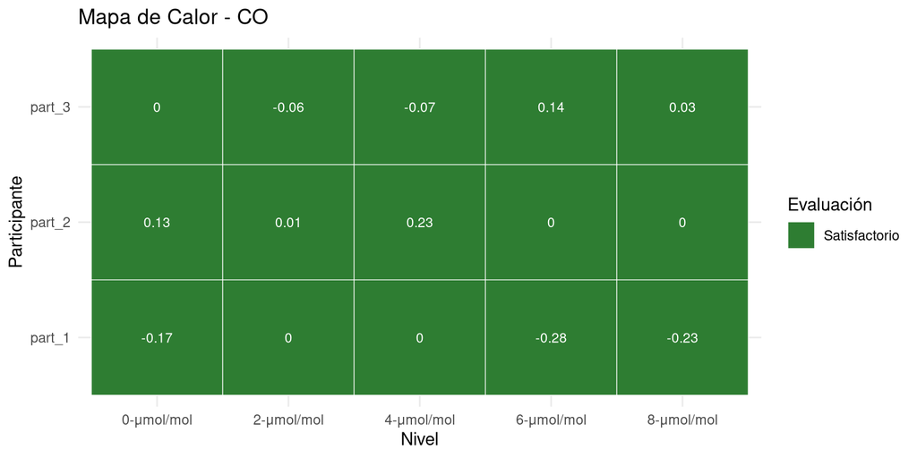

Figura. Mapa de Calor para las puntuaciones para CO por participante.

### Resultados para NO

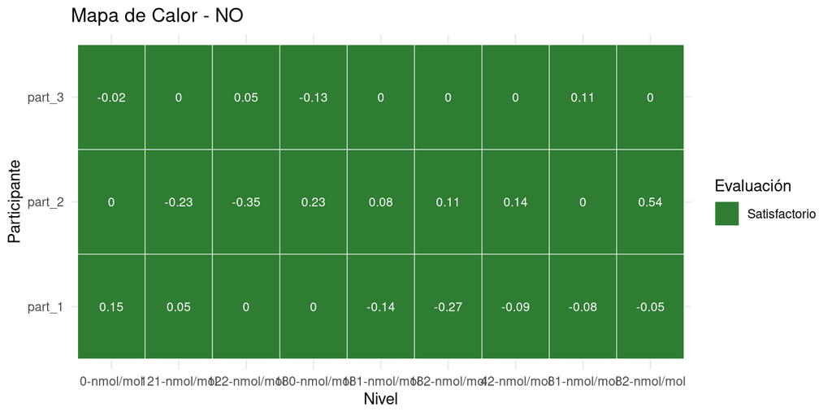

Figura. Mapa de Calor para las puntuaciones para NO por participante.

### Resultados para NO2

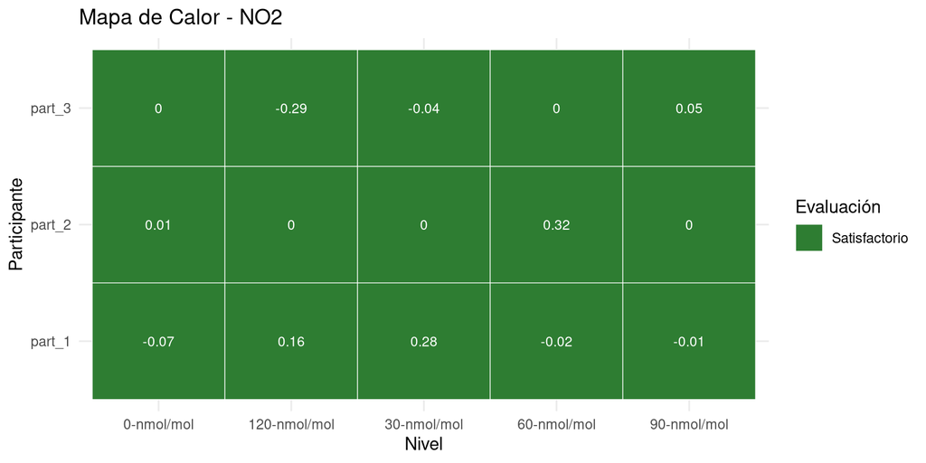

Figura. Mapa de Calor para las puntuaciones para NO2 por participante.

### Resultados para O3

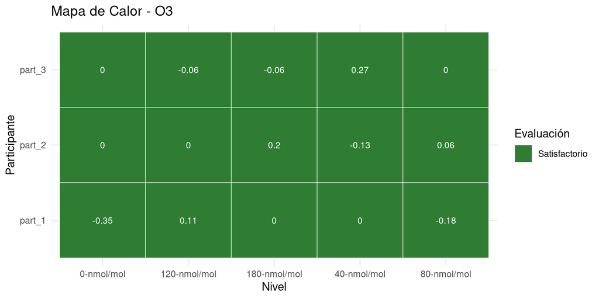

Figura. Mapa de Calor para las puntuaciones para O3 por participante.

### Resultados para SO2

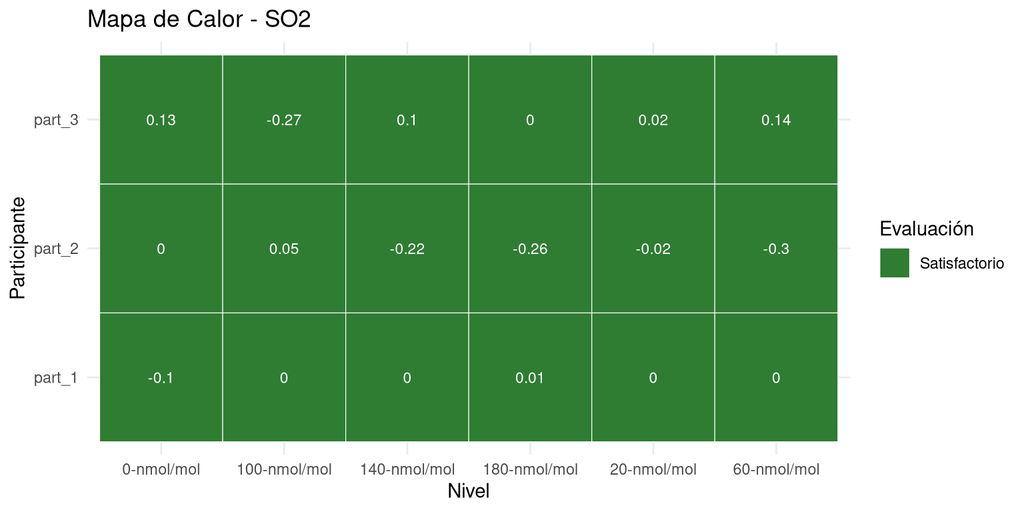

Figura. Mapa de Calor para las puntuaciones para SO2 por participante.

# 5. Conclusiones

**Conformidad General:** El desempeño general de los laboratorios participantes en esta ronda fue positivo.

**Acciones Sugeridas para Participantes:** Se recomienda a los laboratorios con resultados **Cuestionables** ($2.0 < |z| < 3.0$) investigar las posibles causas de la desviación. Se requiere a los laboratorios con resultados **Insatisfactorios** ($|z| \ge 3.0$) realizar una investigación exhaustiva de las causas raíz (e.g., calibración, procedimiento, equipo) e implementar acciones correctivas documentadas.

# Anexo A: Valores Asignados y Desviación Estándar para Evaluación de Aptitud

A continuación se presenta el resumen de los valores asignados ($x_{pt}$), incertidumbres ($u(x_{pt})$) y desviaciones estándar para la evaluación de la aptitud ($\sigma_{pt}$) para cada contaminante y nivel, calculados según el método seleccionado.

Tabla A.1. Resumen de Valores Asignados y Parámetros Estadísticos

| Contaminante | Nivel | Método | Valor Asignado (x_pt) | Incertidumbre u(x_pt) | Desviación (sigma_pt) |
| --- | --- | --- | --- | --- | --- |
| co | 0-μmol/mol | Consenso MADe | -0.0250 | 0.0042 | 0.0058 |
| co | 2-μmol/mol | Consenso MADe | 2.0133 | 0.0001 | 0.0001 |
| co | 4-μmol/mol | Consenso MADe | 4.0244 | 0.0009 | 0.0012 |
| co | 6-μmol/mol | Consenso MADe | 6.0728 | 0.0018 | 0.0025 |
| co | 8-μmol/mol | Consenso MADe | 8.0376 | 0.0018 | 0.0025 |
| no | 0-nmol/mol | Consenso MADe | 0.5418 | 0.0028 | 0.0039 |
| no | 121-nmol/mol | Consenso MADe | 120.3610 | 0.0029 | 0.0041 |
| no | 122-nmol/mol | Consenso MADe | 40.7400 | 0.0029 | 0.0041 |
| no | 180-nmol/mol | Consenso MADe | 182.2686 | 0.0319 | 0.0441 |
| no | 181-nmol/mol | Consenso MADe | 180.2168 | 0.0056 | 0.0078 |
| no | 182-nmol/mol | Consenso MADe | 76.0413 | 0.0371 | 0.0513 |
| no | 42-nmol/mol | Consenso MADe | 24.8822 | 0.1187 | 0.1645 |
| no | 81-nmol/mol | Consenso MADe | 80.6802 | 0.0033 | 0.0046 |
| no | 82-nmol/mol | Consenso MADe | 25.6809 | 0.0047 | 0.0065 |
| no2 | 0-nmol/mol | Consenso MADe | 0.1274 | 0.0014 | 0.0020 |
| no2 | 120-nmol/mol | Consenso MADe | 122.9832 | 0.0734 | 0.1017 |
| no2 | 30-nmol/mol | Consenso MADe | 32.9129 | 0.0014 | 0.0020 |
| no2 | 60-nmol/mol | Consenso MADe | 64.9458 | 0.0048 | 0.0066 |
| no2 | 90-nmol/mol | Consenso MADe | 96.8435 | 0.0004 | 0.0006 |
| o3 | 0-nmol/mol | Consenso MADe | 0.0000 | 0.0000 | 0.0000 |
| o3 | 120-nmol/mol | Consenso MADe | 119.8941 | 0.0484 | 0.0671 |
| o3 | 180-nmol/mol | Consenso MADe | 178.5582 | 0.1365 | 0.1892 |
| o3 | 40-nmol/mol | Consenso MADe | 40.5063 | 0.0465 | 0.0644 |
| o3 | 80-nmol/mol | Consenso MADe | 80.1712 | 0.0363 | 0.0503 |
| so2 | 0-nmol/mol | Consenso MADe | 0.0522 | 0.0046 | 0.0064 |
| so2 | 100-nmol/mol | Consenso MADe | 99.5449 | 0.0286 | 0.0396 |
| so2 | 140-nmol/mol | Consenso MADe | 139.0164 | 0.0557 | 0.0772 |
| so2 | 180-nmol/mol | Consenso MADe | 180.5552 | 0.0050 | 0.0070 |
| so2 | 20-nmol/mol | Consenso MADe | 19.7262 | 0.0008 | 0.0011 |
| so2 | 60-nmol/mol | Consenso MADe | 59.8962 | 0.0046 | 0.0063 |

# Anexo B: Resumen de Homogeneidad y Estabilidad

## B.1. Resumen de Homogeneidad

Tabla B.1. Resumen de Evaluación de Homogeneidad

| Contaminante | Nivel | Items | Réplicas | sigma_pt | u(x_pt) | ss | sw | Criterio c | Cumple | Conclusión |
| --- | --- | --- | --- | --- | --- | --- | --- | --- | --- | --- |
| co | 0-μmol/mol | 10 | 3 | 0.0412 | 0.0163 | 1.8131 | 3.5950 | 0.0124 | No | ss (1.8131) > c_criterion (0.0124): NO CUMPLE CRITERIO HOMOGENEIDAD ss (1.8131) <= c_expanded (3.6130): CUMPLE CRITERIO EXP HOMOGENEIDAD |
| co | 2-μmol/mol | 10 | 3 | 0.0053 | 0.0021 | 1.1185 | 2.6083 | 0.0016 | No | ss (1.1185) > c_criterion (0.0016): NO CUMPLE CRITERIO HOMOGENEIDAD ss (1.1185) <= c_expanded (2.6214): CUMPLE CRITERIO EXP HOMOGENEIDAD |
| co | 4-μmol/mol | 10 | 3 | 0.0112 | 0.0044 | 0.3893 | 1.8680 | 0.0034 | No | ss (0.3893) > c_criterion (0.0034): NO CUMPLE CRITERIO HOMOGENEIDAD ss (0.3893) <= c_expanded (1.8774): CUMPLE CRITERIO EXP HOMOGENEIDAD |
| co | 6-μmol/mol | 10 | 3 | 0.0060 | 0.0024 | 0.2659 | 1.6889 | 0.0018 | No | ss (0.2659) > c_criterion (0.0018): NO CUMPLE CRITERIO HOMOGENEIDAD ss (0.2659) <= c_expanded (1.6973): CUMPLE CRITERIO EXP HOMOGENEIDAD |
| co | 8-μmol/mol | 10 | 3 | 0.0188 | 0.0074 | 0.8012 | 2.2169 | 0.0056 | No | ss (0.8012) > c_criterion (0.0056): NO CUMPLE CRITERIO HOMOGENEIDAD ss (0.8012) <= c_expanded (2.2280): CUMPLE CRITERIO EXP HOMOGENEIDAD |
| no | 0-nmol/mol | 10 | 3 | 0.0690 | 0.0273 | 1.6164 | 3.2863 | 0.0207 | No | ss (1.6164) > c_criterion (0.0207): NO CUMPLE CRITERIO HOMOGENEIDAD ss (1.6164) <= c_expanded (3.3028): CUMPLE CRITERIO EXP HOMOGENEIDAD |
| no | 121-nmol/mol | 10 | 3 | 0.0425 | 0.0168 | 38.2835 | 66.3320 | 0.0127 | No | ss (38.2835) > c_criterion (0.0127): NO CUMPLE CRITERIO HOMOGENEIDAD ss (38.2835) <= c_expanded (66.6628): CUMPLE CRITERIO EXP HOMOGENEIDAD |
| no | 122-nmol/mol | 10 | 3 | 0.0335 | 0.0133 | 11.7432 | 20.4149 | 0.0101 | No | ss (11.7432) > c_criterion (0.0101): NO CUMPLE CRITERIO HOMOGENEIDAD ss (11.7432) <= c_expanded (20.5168): CUMPLE CRITERIO EXP HOMOGENEIDAD |
| no | 180-nmol/mol | 10 | 3 | 0.1211 | 0.0479 | 58.9230 | 102.0725 | 0.0363 | No | ss (58.9230) > c_criterion (0.0363): NO CUMPLE CRITERIO HOMOGENEIDAD ss (58.9230) <= c_expanded (102.5816): CUMPLE CRITERIO EXP HOMOGENEIDAD |
| no | 181-nmol/mol | 10 | 3 | 0.0629 | 0.0249 | 58.2386 | 100.8870 | 0.0189 | No | ss (58.2386) > c_criterion (0.0189): NO CUMPLE CRITERIO HOMOGENEIDAD ss (58.2386) <= c_expanded (101.3902): CUMPLE CRITERIO EXP HOMOGENEIDAD |
| no | 182-nmol/mol | 10 | 3 | 0.3715 | 0.1468 | 23.5422 | 40.8200 | 0.1115 | No | ss (23.5422) > c_criterion (0.1115): NO CUMPLE CRITERIO HOMOGENEIDAD ss (23.5422) <= c_expanded (41.0239): CUMPLE CRITERIO EXP HOMOGENEIDAD |
| no | 42-nmol/mol | 10 | 3 | 1.0612 | 0.4195 | 6.4209 | 11.2902 | 0.3184 | No | ss (6.4209) > c_criterion (0.3184): NO CUMPLE CRITERIO HOMOGENEIDAD ss (6.4209) <= c_expanded (11.3549): CUMPLE CRITERIO EXP HOMOGENEIDAD |
| no | 81-nmol/mol | 10 | 3 | 0.0391 | 0.0154 | 25.0639 | 43.4461 | 0.0117 | No | ss (25.0639) > c_criterion (0.0117): NO CUMPLE CRITERIO HOMOGENEIDAD ss (25.0639) <= c_expanded (43.6628): CUMPLE CRITERIO EXP HOMOGENEIDAD |
| no | 82-nmol/mol | 10 | 3 | 0.0639 | 0.0253 | 6.7357 | 11.7946 | 0.0192 | No | ss (6.7357) > c_criterion (0.0192): NO CUMPLE CRITERIO HOMOGENEIDAD ss (6.7357) <= c_expanded (11.8534): CUMPLE CRITERIO EXP HOMOGENEIDAD |
| no2 | 0-nmol/mol | 10 | 3 | 0.0575 | 0.0227 | 1.7857 | 3.5577 | 0.0173 | No | ss (1.7857) > c_criterion (0.0173): NO CUMPLE CRITERIO HOMOGENEIDAD ss (1.7857) <= c_expanded (3.5755): CUMPLE CRITERIO EXP HOMOGENEIDAD |
| no2 | 120-nmol/mol | 10 | 3 | 0.5247 | 0.2074 | 39.0978 | 67.7433 | 0.1574 | No | ss (39.0978) > c_criterion (0.1574): NO CUMPLE CRITERIO HOMOGENEIDAD ss (39.0978) <= c_expanded (68.0815): CUMPLE CRITERIO EXP HOMOGENEIDAD |
| no2 | 30-nmol/mol | 10 | 3 | 0.0214 | 0.0084 | 9.1385 | 15.9246 | 0.0064 | No | ss (9.1385) > c_criterion (0.0064): NO CUMPLE CRITERIO HOMOGENEIDAD ss (9.1385) <= c_expanded (16.0040): CUMPLE CRITERIO EXP HOMOGENEIDAD |
| no2 | 60-nmol/mol | 10 | 3 | 0.1480 | 0.0585 | 19.8069 | 34.3495 | 0.0444 | No | ss (19.8069) > c_criterion (0.0444): NO CUMPLE CRITERIO HOMOGENEIDAD ss (19.8069) <= c_expanded (34.5209): CUMPLE CRITERIO EXP HOMOGENEIDAD |
| no2 | 90-nmol/mol | 10 | 3 | 0.0664 | 0.0262 | 30.4412 | 52.7551 | 0.0199 | No | ss (30.4412) > c_criterion (0.0199): NO CUMPLE CRITERIO HOMOGENEIDAD ss (30.4412) <= c_expanded (53.0183): CUMPLE CRITERIO EXP HOMOGENEIDAD |
| o3 | 0-nmol/mol | 10 | 3 | 0.0000 | 0.0000 | 1.8053 | 3.5823 | 0.0000 | No | ss (1.8053) > c_criterion (0.0000): NO CUMPLE CRITERIO HOMOGENEIDAD ss (1.8053) <= c_expanded (3.6002): CUMPLE CRITERIO EXP HOMOGENEIDAD |
| o3 | 120-nmol/mol | 10 | 3 | 1.2393 | 0.4899 | 38.0897 | 66.0153 | 0.3718 | No | ss (38.0897) > c_criterion (0.3718): NO CUMPLE CRITERIO HOMOGENEIDAD ss (38.0897) <= c_expanded (66.3466): CUMPLE CRITERIO EXP HOMOGENEIDAD |
| o3 | 180-nmol/mol | 10 | 3 | 0.2533 | 0.1001 | 57.5698 | 99.7504 | 0.0760 | No | ss (57.5698) > c_criterion (0.0760): NO CUMPLE CRITERIO HOMOGENEIDAD ss (57.5698) <= c_expanded (100.2480): CUMPLE CRITERIO EXP HOMOGENEIDAD |
| o3 | 40-nmol/mol | 10 | 3 | 0.0763 | 0.0302 | 11.6938 | 20.3139 | 0.0229 | No | ss (11.6938) > c_criterion (0.0229): NO CUMPLE CRITERIO HOMOGENEIDAD ss (11.6938) <= c_expanded (20.4152): CUMPLE CRITERIO EXP HOMOGENEIDAD |
| o3 | 80-nmol/mol | 10 | 3 | 0.0602 | 0.0238 | 24.7970 | 42.9794 | 0.0181 | No | ss (24.7970) > c_criterion (0.0181): NO CUMPLE CRITERIO HOMOGENEIDAD ss (24.7970) <= c_expanded (43.1937): CUMPLE CRITERIO EXP HOMOGENEIDAD |
| so2 | 0-nmol/mol | 10 | 3 | 0.0406 | 0.0160 | 1.7929 | 3.5637 | 0.0122 | No | ss (1.7929) > c_criterion (0.0122): NO CUMPLE CRITERIO HOMOGENEIDAD ss (1.7929) <= c_expanded (3.5815): CUMPLE CRITERIO EXP HOMOGENEIDAD |
| so2 | 100-nmol/mol | 10 | 3 | 0.7757 | 0.3066 | 31.3239 | 54.2817 | 0.2327 | No | ss (31.3239) > c_criterion (0.2327): NO CUMPLE CRITERIO HOMOGENEIDAD ss (31.3239) <= c_expanded (54.5534): CUMPLE CRITERIO EXP HOMOGENEIDAD |
| so2 | 140-nmol/mol | 10 | 3 | 0.1313 | 0.0519 | 44.5305 | 77.1528 | 0.0394 | No | ss (44.5305) > c_criterion (0.0394): NO CUMPLE CRITERIO HOMOGENEIDAD ss (44.5305) <= c_expanded (77.5376): CUMPLE CRITERIO EXP HOMOGENEIDAD |
| so2 | 180-nmol/mol | 10 | 3 | 0.1208 | 0.0477 | 58.3632 | 101.1001 | 0.0362 | No | ss (58.3632) > c_criterion (0.0362): NO CUMPLE CRITERIO HOMOGENEIDAD ss (58.3632) <= c_expanded (101.6044): CUMPLE CRITERIO EXP HOMOGENEIDAD |
| so2 | 20-nmol/mol | 10 | 3 | 0.0227 | 0.0090 | 4.7271 | 8.3729 | 0.0068 | No | ss (4.7271) > c_criterion (0.0068): NO CUMPLE CRITERIO HOMOGENEIDAD ss (4.7271) <= c_expanded (8.4146): CUMPLE CRITERIO EXP HOMOGENEIDAD |
| so2 | 60-nmol/mol | 10 | 3 | 0.0295 | 0.0117 | 18.1302 | 31.4514 | 0.0089 | No | ss (18.1302) > c_criterion (0.0089): NO CUMPLE CRITERIO HOMOGENEIDAD ss (18.1302) <= c_expanded (31.6082): CUMPLE CRITERIO EXP HOMOGENEIDAD |

## B.2. Resumen de Estabilidad

Tabla B.2. Resumen de Evaluación de Estabilidad

| Contaminante | Nivel | Items | Réplicas | sigma_pt | u(x_pt) | Diferencia | Criterio c | Cumple | Conclusión |
| --- | --- | --- | --- | --- | --- | --- | --- | --- | --- |
| co | 0-μmol/mol | 2 | 3 | 0.0395 | 0.0349 | 1.3313 | 0.0124 | No | ss (1.3313) > c_criterion (0.0124): NO CUMPLE CRITERIO ESTABILIDAD ss (1.3313) > c_expanded (0.8558): NO CUMPLE CRITERIO EXP ESTABILIDAD |
| co | 2-μmol/mol | 2 | 3 | 0.0004 | 0.0004 | 1.3363 | 0.0016 | No | ss (1.3363) > c_criterion (0.0016): NO CUMPLE CRITERIO ESTABILIDAD ss (1.3363) > c_expanded (0.5891): NO CUMPLE CRITERIO EXP ESTABILIDAD |
| co | 4-μmol/mol | 2 | 3 | 0.0020 | 0.0018 | 1.3274 | 0.0034 | No | ss (1.3274) > c_criterion (0.0034): NO CUMPLE CRITERIO ESTABILIDAD ss (1.3274) > c_expanded (1.2017): NO CUMPLE CRITERIO EXP ESTABILIDAD |
| co | 6-μmol/mol | 2 | 3 | 0.0195 | 0.0172 | 1.3288 | 0.0018 | No | ss (1.3288) > c_criterion (0.0018): NO CUMPLE CRITERIO ESTABILIDAD ss (1.3288) <= c_expanded (2.0055): CUMPLE CRITERIO EXP ESTABILIDAD |
| co | 8-μmol/mol | 2 | 3 | 0.0126 | 0.0112 | 1.3413 | 0.0056 | No | ss (1.3413) > c_criterion (0.0056): NO CUMPLE CRITERIO ESTABILIDAD ss (1.3413) <= c_expanded (2.8075): CUMPLE CRITERIO EXP ESTABILIDAD |
| no | 0-nmol/mol | 2 | 3 | 0.1783 | 0.1576 | 1.2963 | 0.0207 | No | ss (1.2963) > c_criterion (0.0207): NO CUMPLE CRITERIO ESTABILIDAD ss (1.2963) <= c_expanded (7.6914): CUMPLE CRITERIO EXP ESTABILIDAD |
| no | 121-nmol/mol | 2 | 3 | 0.0560 | 0.0495 | 1.3348 | 0.0127 | No | ss (1.3348) > c_criterion (0.0127): NO CUMPLE CRITERIO ESTABILIDAD ss (1.3348) <= c_expanded (50.7076): CUMPLE CRITERIO EXP ESTABILIDAD |
| no | 122-nmol/mol | 2 | 3 | 0.0171 | 0.0151 | 1.3302 | 0.0101 | No | ss (1.3302) > c_criterion (0.0101): NO CUMPLE CRITERIO ESTABILIDAD ss (1.3302) <= c_expanded (18.2461): CUMPLE CRITERIO EXP ESTABILIDAD |
| no | 180-nmol/mol | 2 | 3 | 0.0420 | 0.0371 | 1.4103 | 0.0363 | No | ss (1.4103) > c_criterion (0.0363): NO CUMPLE CRITERIO ESTABILIDAD ss (1.4103) <= c_expanded (76.5919): CUMPLE CRITERIO EXP ESTABILIDAD |
| no | 181-nmol/mol | 2 | 3 | 0.0685 | 0.0606 | 1.3039 | 0.0189 | No | ss (1.3039) > c_criterion (0.0189): NO CUMPLE CRITERIO ESTABILIDAD ss (1.3039) <= c_expanded (75.7799): CUMPLE CRITERIO EXP ESTABILIDAD |
| no | 182-nmol/mol | 2 | 3 | 0.0443 | 0.0392 | 1.4344 | 0.1115 | No | ss (1.4344) > c_criterion (0.1115): NO CUMPLE CRITERIO ESTABILIDAD ss (1.4344) <= c_expanded (32.4427): CUMPLE CRITERIO EXP ESTABILIDAD |
| no | 42-nmol/mol | 2 | 3 | 0.7695 | 0.6802 | 1.2003 | 0.3184 | No | ss (1.2003) > c_criterion (0.3184): NO CUMPLE CRITERIO ESTABILIDAD ss (1.2003) <= c_expanded (12.8431): CUMPLE CRITERIO EXP ESTABILIDAD |
| no | 81-nmol/mol | 2 | 3 | 0.0458 | 0.0405 | 1.3451 | 0.0117 | No | ss (1.3451) > c_criterion (0.0117): NO CUMPLE CRITERIO ESTABILIDAD ss (1.3451) <= c_expanded (34.2639): CUMPLE CRITERIO EXP ESTABILIDAD |
| no | 82-nmol/mol | 2 | 3 | 0.0753 | 0.0665 | 1.3149 | 0.0192 | No | ss (1.3149) > c_criterion (0.0192): NO CUMPLE CRITERIO ESTABILIDAD ss (1.3149) <= c_expanded (12.7967): CUMPLE CRITERIO EXP ESTABILIDAD |
| no2 | 0-nmol/mol | 2 | 3 | 0.2026 | 0.1791 | 1.2650 | 0.0173 | No | ss (1.2650) > c_criterion (0.0173): NO CUMPLE CRITERIO ESTABILIDAD ss (1.2650) <= c_expanded (7.4252): CUMPLE CRITERIO EXP ESTABILIDAD |
| no2 | 120-nmol/mol | 2 | 3 | 0.2544 | 0.2248 | 1.5644 | 0.1574 | No | ss (1.5644) > c_criterion (0.1574): NO CUMPLE CRITERIO ESTABILIDAD ss (1.5644) <= c_expanded (51.6885): CUMPLE CRITERIO EXP ESTABILIDAD |
| no2 | 30-nmol/mol | 2 | 3 | 0.1043 | 0.0922 | 1.3197 | 0.0064 | No | ss (1.3197) > c_criterion (0.0064): NO CUMPLE CRITERIO ESTABILIDAD ss (1.3197) <= c_expanded (15.1858): CUMPLE CRITERIO EXP ESTABILIDAD |
| no2 | 60-nmol/mol | 2 | 3 | 0.2893 | 0.2557 | 1.2702 | 0.0444 | No | ss (1.2702) > c_criterion (0.0444): NO CUMPLE CRITERIO ESTABILIDAD ss (1.2702) <= c_expanded (27.8255): CUMPLE CRITERIO EXP ESTABILIDAD |
| no2 | 90-nmol/mol | 2 | 3 | 0.0655 | 0.0579 | 1.3224 | 0.0199 | No | ss (1.3224) > c_criterion (0.0199): NO CUMPLE CRITERIO ESTABILIDAD ss (1.3224) <= c_expanded (40.8941): CUMPLE CRITERIO EXP ESTABILIDAD |
| o3 | 0-nmol/mol | 2 | 3 | 0.0000 | 0.0000 | 1.3333 | 0.0000 | No | ss (1.3333) > c_criterion (0.0000): NO CUMPLE CRITERIO ESTABILIDAD ss (1.3333) <= c_expanded (10.2705): CUMPLE CRITERIO EXP ESTABILIDAD |
| o3 | 120-nmol/mol | 2 | 3 | 1.1792 | 1.0423 | 1.5448 | 0.3718 | No | ss (1.5448) > c_criterion (0.3718): NO CUMPLE CRITERIO ESTABILIDAD ss (1.5448) <= c_expanded (51.1703): CUMPLE CRITERIO EXP ESTABILIDAD |
| o3 | 180-nmol/mol | 2 | 3 | 0.0098 | 0.0087 | 1.1867 | 0.0760 | No | ss (1.1867) > c_criterion (0.0760): NO CUMPLE CRITERIO ESTABILIDAD ss (1.1867) <= c_expanded (75.4001): CUMPLE CRITERIO EXP ESTABILIDAD |
| o3 | 40-nmol/mol | 2 | 3 | 0.4936 | 0.4363 | 1.3255 | 0.0229 | No | ss (1.3255) > c_criterion (0.0229): NO CUMPLE CRITERIO ESTABILIDAD ss (1.3255) <= c_expanded (19.4240): CUMPLE CRITERIO EXP ESTABILIDAD |
| o3 | 80-nmol/mol | 2 | 3 | 0.0425 | 0.0376 | 1.1891 | 0.0181 | No | ss (1.1891) > c_criterion (0.0181): NO CUMPLE CRITERIO ESTABILIDAD ss (1.1891) <= c_expanded (34.7078): CUMPLE CRITERIO EXP ESTABILIDAD |
| so2 | 0-nmol/mol | 2 | 3 | 0.0825 | 0.0730 | 1.3399 | 0.0122 | No | ss (1.3399) > c_criterion (0.0122): NO CUMPLE CRITERIO ESTABILIDAD ss (1.3399) <= c_expanded (8.3328): CUMPLE CRITERIO EXP ESTABILIDAD |
| so2 | 100-nmol/mol | 2 | 3 | 0.0450 | 0.0398 | 1.4668 | 0.2327 | No | ss (1.4668) > c_criterion (0.2327): NO CUMPLE CRITERIO ESTABILIDAD ss (1.4668) <= c_expanded (42.2842): CUMPLE CRITERIO EXP ESTABILIDAD |
| so2 | 140-nmol/mol | 2 | 3 | 0.6377 | 0.5636 | 1.3301 | 0.0394 | No | ss (1.3301) > c_criterion (0.0394): NO CUMPLE CRITERIO ESTABILIDAD ss (1.3301) <= c_expanded (58.6508): CUMPLE CRITERIO EXP ESTABILIDAD |
| so2 | 180-nmol/mol | 2 | 3 | 0.7725 | 0.6828 | 1.5282 | 0.0362 | No | ss (1.5282) > c_criterion (0.0362): NO CUMPLE CRITERIO ESTABILIDAD ss (1.5282) <= c_expanded (75.8773): CUMPLE CRITERIO EXP ESTABILIDAD |
| so2 | 20-nmol/mol | 2 | 3 | 0.0236 | 0.0208 | 1.3128 | 0.0068 | No | ss (1.3128) > c_criterion (0.0068): NO CUMPLE CRITERIO ESTABILIDAD ss (1.3128) <= c_expanded (11.3220): CUMPLE CRITERIO EXP ESTABILIDAD |
| so2 | 60-nmol/mol | 2 | 3 | 0.0008 | 0.0007 | 1.3581 | 0.0089 | No | ss (1.3581) > c_criterion (0.0089): NO CUMPLE CRITERIO ESTABILIDAD ss (1.3581) <= c_expanded (25.9779): CUMPLE CRITERIO EXP ESTABILIDAD |

# Anexo C: Resultados por Participante

A continuación se presentan los resultados detallados para cada participante.

## Código: part_1

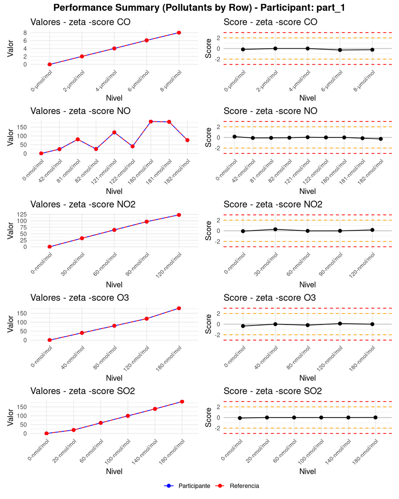

Figura. Matriz de desempeño para el participante part_1

### Tabla de Resultados

Resultados detallados - Participante part_1

| Contaminante | Nivel | Resultado | Incertidumbre | Valor Asignado | Incertidumbre VA | Score | Evaluación |
| --- | --- | --- | --- | --- | --- | --- | --- |
| co | 0-μmol/mol | -0.0296 | 0.0274 | -0.0250 | 0.0042 | -0.1680 | Satisfactorio |
| co | 2-μmol/mol | 2.0133 | 0.0035 | 2.0133 | 0.0001 | 0.0000 | Satisfactorio |
| co | 4-μmol/mol | 4.0244 | 0.0131 | 4.0244 | 0.0009 | 0.0000 | Satisfactorio |
| co | 6-μmol/mol | 6.0691 | 0.0133 | 6.0728 | 0.0018 | -0.2789 | Satisfactorio |
| co | 8-μmol/mol | 8.0241 | 0.0589 | 8.0376 | 0.0018 | -0.2297 | Satisfactorio |
| no | 0-nmol/mol | 0.5646 | 0.1500 | 0.5418 | 0.0028 | 0.1518 | Satisfactorio |
| no | 121-nmol/mol | 120.3638 | 0.0608 | 120.3610 | 0.0029 | 0.0452 | Satisfactorio |
| no | 122-nmol/mol | 40.7400 | 0.0434 | 40.7400 | 0.0029 | 0.0000 | Satisfactorio |
| no | 180-nmol/mol | 182.2686 | 0.2655 | 182.2686 | 0.0319 | 0.0000 | Satisfactorio |
| no | 181-nmol/mol | 180.2036 | 0.0915 | 180.2168 | 0.0056 | -0.1438 | Satisfactorio |
| no | 182-nmol/mol | 75.9568 | 0.3148 | 76.0413 | 0.0371 | -0.2667 | Satisfactorio |
| no | 42-nmol/mol | 24.7712 | 1.1783 | 24.8822 | 0.1187 | -0.0937 | Satisfactorio |
| no | 81-nmol/mol | 80.6771 | 0.0376 | 80.6802 | 0.0033 | -0.0824 | Satisfactorio |
| no | 82-nmol/mol | 25.6766 | 0.0835 | 25.6809 | 0.0047 | -0.0520 | Satisfactorio |
| no2 | 0-nmol/mol | 0.1156 | 0.1767 | 0.1274 | 0.0014 | -0.0668 | Satisfactorio |
| no2 | 120-nmol/mol | 123.0519 | 0.4097 | 122.9832 | 0.0734 | 0.1648 | Satisfactorio |
| no2 | 30-nmol/mol | 32.9221 | 0.0322 | 32.9129 | 0.0014 | 0.2830 | Satisfactorio |
| no2 | 60-nmol/mol | 64.9414 | 0.2888 | 64.9458 | 0.0048 | -0.0154 | Satisfactorio |
| no2 | 90-nmol/mol | 96.8431 | 0.0392 | 96.8435 | 0.0004 | -0.0098 | Satisfactorio |
| o3 | 0-nmol/mol | 0.0000 | 0.0000 | 0.0000 | 0.0000 | -0.3523 | Satisfactorio |
| o3 | 120-nmol/mol | 119.9869 | 0.8343 | 119.8941 | 0.0484 | 0.1110 | Satisfactorio |
| o3 | 180-nmol/mol | 178.5582 | 1.7407 | 178.5582 | 0.1365 | 0.0000 | Satisfactorio |
| o3 | 40-nmol/mol | 40.5063 | 0.3185 | 40.5063 | 0.0465 | 0.0000 | Satisfactorio |
| o3 | 80-nmol/mol | 80.0629 | 0.5854 | 80.1712 | 0.0363 | -0.1847 | Satisfactorio |
| so2 | 0-nmol/mol | 0.0472 | 0.0496 | 0.0522 | 0.0046 | -0.1011 | Satisfactorio |
| so2 | 100-nmol/mol | 99.5449 | 0.5870 | 99.5449 | 0.0286 | 0.0000 | Satisfactorio |
| so2 | 140-nmol/mol | 139.0164 | 0.4760 | 139.0164 | 0.0557 | 0.0000 | Satisfactorio |
| so2 | 180-nmol/mol | 180.5599 | 0.4259 | 180.5552 | 0.0050 | 0.0110 | Satisfactorio |
| so2 | 20-nmol/mol | 19.7262 | 0.0440 | 19.7262 | 0.0008 | 0.0000 | Satisfactorio |
| so2 | 60-nmol/mol | 59.8962 | 0.0493 | 59.8962 | 0.0046 | 0.0000 | Satisfactorio |

## Código: part_2

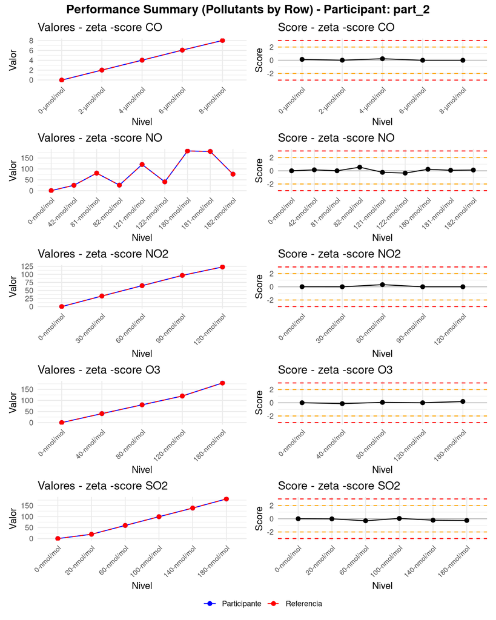

Figura. Matriz de desempeño para el participante part_2

### Tabla de Resultados

Resultados detallados - Participante part_2

| Contaminante | Nivel | Resultado | Incertidumbre | Valor Asignado | Incertidumbre VA | Score | Evaluación |
| --- | --- | --- | --- | --- | --- | --- | --- |
| co | 0-μmol/mol | -0.0211 | 0.0288 | -0.0250 | 0.0042 | 0.1342 | Satisfactorio |
| co | 2-μmol/mol | 2.0134 | 0.0042 | 2.0133 | 0.0001 | 0.0142 | Satisfactorio |
| co | 4-μmol/mol | 4.0272 | 0.0118 | 4.0244 | 0.0009 | 0.2345 | Satisfactorio |
| co | 6-μmol/mol | 6.0728 | 0.0139 | 6.0728 | 0.0018 | 0.0000 | Satisfactorio |
| co | 8-μmol/mol | 8.0376 | 0.0593 | 8.0376 | 0.0018 | 0.0000 | Satisfactorio |
| no | 0-nmol/mol | 0.5418 | 0.1210 | 0.5418 | 0.0028 | 0.0000 | Satisfactorio |
| no | 121-nmol/mol | 120.3424 | 0.0791 | 120.3610 | 0.0029 | -0.2347 | Satisfactorio |
| no | 122-nmol/mol | 40.7224 | 0.0502 | 40.7400 | 0.0029 | -0.3501 | Satisfactorio |
| no | 180-nmol/mol | 182.3227 | 0.2345 | 182.2686 | 0.0319 | 0.2283 | Satisfactorio |
| no | 181-nmol/mol | 180.2220 | 0.0647 | 180.2168 | 0.0056 | 0.0809 | Satisfactorio |
| no | 182-nmol/mol | 76.0759 | 0.3005 | 76.0413 | 0.0371 | 0.1143 | Satisfactorio |
| no | 42-nmol/mol | 25.0148 | 0.9188 | 24.8822 | 0.1187 | 0.1432 | Satisfactorio |
| no | 81-nmol/mol | 80.6802 | 0.0411 | 80.6802 | 0.0033 | 0.0000 | Satisfactorio |
| no | 82-nmol/mol | 25.7165 | 0.0652 | 25.6809 | 0.0047 | 0.5446 | Satisfactorio |
| no2 | 0-nmol/mol | 0.1287 | 0.1811 | 0.1274 | 0.0014 | 0.0073 | Satisfactorio |
| no2 | 120-nmol/mol | 122.9832 | 0.3376 | 122.9832 | 0.0734 | 0.0000 | Satisfactorio |
| no2 | 30-nmol/mol | 32.9129 | 0.0312 | 32.9129 | 0.0014 | 0.0000 | Satisfactorio |
| no2 | 60-nmol/mol | 65.0075 | 0.1911 | 64.9458 | 0.0048 | 0.3224 | Satisfactorio |
| no2 | 90-nmol/mol | 96.8435 | 0.0383 | 96.8435 | 0.0004 | 0.0000 | Satisfactorio |
| o3 | 0-nmol/mol | 0.0000 | 0.0000 | 0.0000 | 0.0000 | 0.0000 | Satisfactorio |
| o3 | 120-nmol/mol | 119.8941 | 0.8338 | 119.8941 | 0.0484 | 0.0000 | Satisfactorio |
| o3 | 180-nmol/mol | 178.9456 | 1.9614 | 178.5582 | 0.1365 | 0.1970 | Satisfactorio |
| o3 | 40-nmol/mol | 40.4629 | 0.3215 | 40.5063 | 0.0465 | -0.1337 | Satisfactorio |
| o3 | 80-nmol/mol | 80.2051 | 0.5810 | 80.1712 | 0.0363 | 0.0583 | Satisfactorio |
| so2 | 0-nmol/mol | 0.0522 | 0.0368 | 0.0522 | 0.0046 | 0.0000 | Satisfactorio |
| so2 | 100-nmol/mol | 99.5716 | 0.5696 | 99.5449 | 0.0286 | 0.0468 | Satisfactorio |
| so2 | 140-nmol/mol | 138.9130 | 0.4694 | 139.0164 | 0.0557 | -0.2188 | Satisfactorio |
| so2 | 180-nmol/mol | 180.4591 | 0.3761 | 180.5552 | 0.0050 | -0.2556 | Satisfactorio |
| so2 | 20-nmol/mol | 19.7255 | 0.0399 | 19.7262 | 0.0008 | -0.0186 | Satisfactorio |
| so2 | 60-nmol/mol | 59.8870 | 0.0300 | 59.8962 | 0.0046 | -0.3040 | Satisfactorio |

## Código: part_3

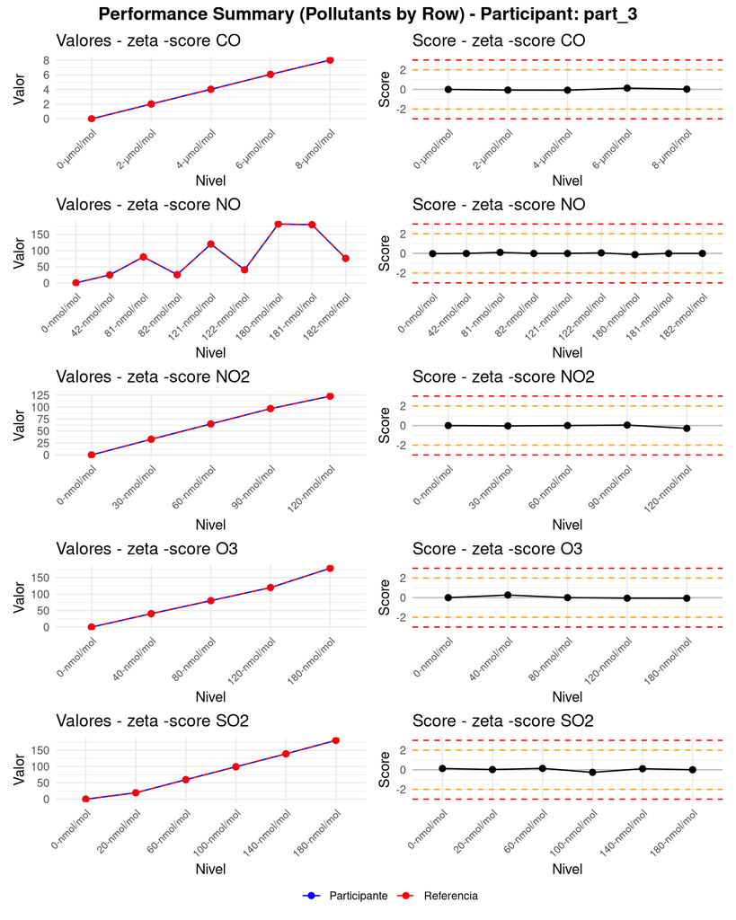

Figura. Matriz de desempeño para el participante part_3

### Tabla de Resultados

Resultados detallados - Participante part_3

| Contaminante | Nivel | Resultado | Incertidumbre | Valor Asignado | Incertidumbre VA | Score | Evaluación |
| --- | --- | --- | --- | --- | --- | --- | --- |
| co | 0-μmol/mol | -0.0250 | 0.0284 | -0.0250 | 0.0042 | 0.0000 | Satisfactorio |
| co | 2-μmol/mol | 2.0130 | 0.0042 | 2.0133 | 0.0001 | -0.0631 | Satisfactorio |
| co | 4-μmol/mol | 4.0236 | 0.0112 | 4.0244 | 0.0009 | -0.0734 | Satisfactorio |
| co | 6-μmol/mol | 6.0746 | 0.0126 | 6.0728 | 0.0018 | 0.1351 | Satisfactorio |
| co | 8-μmol/mol | 8.0393 | 0.0565 | 8.0376 | 0.0018 | 0.0294 | Satisfactorio |
| no | 0-nmol/mol | 0.5391 | 0.1147 | 0.5418 | 0.0028 | -0.0230 | Satisfactorio |
| no | 121-nmol/mol | 120.3610 | 0.0602 | 120.3610 | 0.0029 | 0.0000 | Satisfactorio |
| no | 122-nmol/mol | 40.7427 | 0.0527 | 40.7400 | 0.0029 | 0.0518 | Satisfactorio |
| no | 180-nmol/mol | 182.2389 | 0.2358 | 182.2686 | 0.0319 | -0.1251 | Satisfactorio |
| no | 181-nmol/mol | 180.2168 | 0.0635 | 180.2168 | 0.0056 | 0.0000 | Satisfactorio |
| no | 182-nmol/mol | 76.0413 | 0.3233 | 76.0413 | 0.0371 | 0.0000 | Satisfactorio |
| no | 42-nmol/mol | 24.8822 | 1.0370 | 24.8822 | 0.1187 | 0.0000 | Satisfactorio |
| no | 81-nmol/mol | 80.6840 | 0.0355 | 80.6802 | 0.0033 | 0.1060 | Satisfactorio |
| no | 82-nmol/mol | 25.6809 | 0.0568 | 25.6809 | 0.0047 | 0.0000 | Satisfactorio |
| no2 | 0-nmol/mol | 0.1274 | 0.1800 | 0.1274 | 0.0014 | 0.0000 | Satisfactorio |
| no2 | 120-nmol/mol | 122.8776 | 0.3599 | 122.9832 | 0.0734 | -0.2877 | Satisfactorio |
| no2 | 30-nmol/mol | 32.9116 | 0.0365 | 32.9129 | 0.0014 | -0.0366 | Satisfactorio |
| no2 | 60-nmol/mol | 64.9458 | 0.2231 | 64.9458 | 0.0048 | 0.0000 | Satisfactorio |
| no2 | 90-nmol/mol | 96.8450 | 0.0315 | 96.8435 | 0.0004 | 0.0481 | Satisfactorio |
| o3 | 0-nmol/mol | 0.0000 | 0.0000 | 0.0000 | 0.0000 | 0.0011 | Satisfactorio |
| o3 | 120-nmol/mol | 119.8489 | 0.8192 | 119.8941 | 0.0484 | -0.0551 | Satisfactorio |
| o3 | 180-nmol/mol | 178.4306 | 2.0779 | 178.5582 | 0.1365 | -0.0613 | Satisfactorio |
| o3 | 40-nmol/mol | 40.5903 | 0.3129 | 40.5063 | 0.0465 | 0.2653 | Satisfactorio |
| o3 | 80-nmol/mol | 80.1712 | 0.5040 | 80.1712 | 0.0363 | 0.0000 | Satisfactorio |
| so2 | 0-nmol/mol | 0.0565 | 0.0337 | 0.0522 | 0.0046 | 0.1274 | Satisfactorio |
| so2 | 100-nmol/mol | 99.3900 | 0.5832 | 99.5449 | 0.0286 | -0.2654 | Satisfactorio |
| so2 | 140-nmol/mol | 139.0685 | 0.4941 | 139.0164 | 0.0557 | 0.1047 | Satisfactorio |
| so2 | 180-nmol/mol | 180.5552 | 0.4021 | 180.5552 | 0.0050 | 0.0000 | Satisfactorio |
| so2 | 20-nmol/mol | 19.7273 | 0.0503 | 19.7262 | 0.0008 | 0.0210 | Satisfactorio |
| so2 | 60-nmol/mol | 59.9005 | 0.0302 | 59.8962 | 0.0046 | 0.1398 | Satisfactorio |